# ECON 142 - Applied Econometrics & Public Policy

### Monte-Carlo Simulation

I now estimate each MP's wave_2 influence using the following process:

For all MPs:

- simulate 10 random cascades (see above)
- store the mean and standard deviation $\sigma$ of those 10 simulations
- compute standard errors as: $SE(\text{Wave_2_influence}) = \frac{\sigma}{\sqrt{10}} $

I present results for different choices of $\Theta$ : $\Theta \in [2, 10, 25, 50, 100]$.

Figuring out a systematic way to optimally choose this parameter would however be very interesting.

```python
# Drop the president of the Natinal Assembly (Bartholone, never votes)
ranking = ranking.loc[ranking["Expected_Direct_Influence"] != 0, :]
```

```python
# will take a while to run

simulated_means2 = []
simulated_std2 = []

for i in ranking.index:
    s = simulate_cascade(i, 0, num_rep = 10, sec_wave_threshold = 2) #for final analysis: use num_rep = 20
    simulated_means2.append(np.mean(s))
    simulated_std2.append(np.std(s))

simulated_means10 = []
simulated_std10 = []

for i in ranking.index:
    s = simulate_cascade(i, 0, num_rep = 10, sec_wave_threshold = 10) #for final analysis: use num_rep = 20
    simulated_means10.append(np.mean(s))
    simulated_std10.append(np.std(s))
```

```python
# will take a while to run

simulated_means25 = []
simulated_std25 = []

for i in ranking.index:
    s = simulate_cascade(i, 0, num_rep = 10, sec_wave_threshold = 25) #for final analysis: use num_rep = 20
    simulated_means25.append(np.mean(s))
    simulated_std25.append(np.std(s))

simulated_means50 = []
simulated_std50 = []

for i in ranking.index:
    s = simulate_cascade(i, 0, num_rep = 10, sec_wave_threshold = 50) #for final analysis: use num_rep = 20
    simulated_means50.append(np.mean(s))
    simulated_std50.append(np.std(s))

simulated_means100 = []
simulated_std100 = []

for i in ranking.index:
    s = simulate_cascade(i, 0, num_rep = 10, sec_wave_threshold = 100) #for final analysis: use num_rep = 20
    simulated_means100.append(np.mean(s))
    simulated_std100.append(np.std(s))
```

```python
ranking["Estimated_2_Waves_Influence_2"] = np.array(simulated_means2)
ranking["wave2se_2"] = np.array(simulated_std2) / np.sqrt(10)

ranking["Estimated_2_Waves_Influence_10"] = np.array(simulated_means10)
ranking["wave2se_10"] = np.array(simulated_std10) / np.sqrt(10)

ranking["Estimated_2_Waves_Influence_25"] = np.array(simulated_means25)
ranking["wave2se_25"] = np.array(simulated_std25) / np.sqrt(10)

ranking["Estimated_2_Waves_Influence_50"] = np.array(simulated_means50)
ranking["wave2se_50"] = np.array(simulated_std50) / np.sqrt(10)

ranking["Estimated_2_Waves_Influence_100"] = np.array(simulated_means100)
ranking["wave2se_100"] = np.array(simulated_std100) / np.sqrt(10)
```

```python
ranking.head()
```

|  | MP | Expected_Direct_Influence | Estimated_2_Waves_Influence_2 | wave2se_2 | Estimated_2_Waves_Influence_10 | wave2se_10 | Estimated_2_Waves_Influence_25 | wave2se_25 | Estimated_2_Waves_Influence_50 | wave2se_50 | Estimated_2_Waves_Influence_100 | wave2se_100 |
| --- | --- | --- | --- | --- | --- | --- | --- | --- | --- | --- | --- | --- |
| 0 | Alain Ballay | 36.039683 | 615.0 | 5.381450 | 345.9 | 4.964776 | 118.7 | 30.699202 | 36.0 | 1.334166 | 38.6 | 1.297690 |
| 1 | Alain Bocquet | 201.142857 | 634.4 | 0.209762 | 621.6 | 0.814862 | 599.6 | 0.603324 | 557.7 | 3.844607 | 216.7 | 7.611899 |
| 2 | Alain Calmette | 294.984127 | 634.3 | 0.202485 | 627.1 | 0.411096 | 600.8 | 2.813539 | 397.6 | 1.422674 | 363.6 | 1.761817 |
| 3 | Alain Chrétien | 212.690476 | 632.6 | 0.352136 | 612.2 | 0.797496 | 552.5 | 5.337134 | 282.8 | 2.053290 | 261.9 | 2.123441 |
| 4 | Alain Claeys | 300.880952 | 634.8 | 0.126491 | 627.2 | 0.394968 | 606.9 | 2.242543 | 406.2 | 2.734227 | 366.8 | 1.793321 |

```python
ranking.to_csv("other_data/full_2_waves_ranking.csv", index = False) # so that I don't have to re-run the simulation
ranking = pd.read_csv("other_data/full_2_waves_ranking.csv")
```

## Analysis

### Depending on her assumption about $\Theta$, the lobbyist can now decide on which MP to target in order to maximize her chance of getting her law adopted:

```python
# ranking by theta
def ranking_waves(theta):
    return ranking.sort_values("Estimated_2_Waves_Influence_{}".format(theta), ascending=False)[["MP", "Estimated_2_Waves_Influence_{}".format(theta), "wave2se_{}".format(theta)]].head()

from IPython.display import display

display("Theta = 2", ranking_waves(2),
        "Theta = 10", ranking_waves(10),
        "Theta = 25", ranking_waves(25),
        "Theta = 50", ranking_waves(50),
        "Theta = 100", ranking_waves(100))
```

```
'Theta = 2'
```

|  | MP | Estimated_2_Waves_Influence_2 | wave2se_2 |
| --- | --- | --- | --- |
| 432 | Michel Lefait | 635.0 | 0.0 |
| 279 | Jean-Claude Buisine | 635.0 | 0.0 |
| 434 | Michel Liebgott | 635.0 | 0.0 |
| 324 | Jean-Paul Chanteguet | 635.0 | 0.0 |
| 567 | Stéphane Saint-André | 635.0 | 0.0 |

```
'Theta = 10'
```

|  | MP | Estimated_2_Waves_Influence_10 | wave2se_10 |
| --- | --- | --- | --- |
| 404 | Marie-Hélène Fabre | 628.2 | 0.419524 |
| 197 | Frédéric Roig | 628.1 | 0.359166 |
| 402 | Marie-Françoise Clergeau | 628.0 | 0.282843 |
| 198 | Frédérique Massat | 628.0 | 0.316228 |
| 435 | Michel Ménard | 627.9 | 0.298329 |

```
'Theta = 25'
```

|  | MP | Estimated_2_Waves_Influence_25 | wave2se_25 |
| --- | --- | --- | --- |
| 541 | Roger-Gérard Schwartzenberg | 613.1 | 0.780385 |
| 352 | Joël Giraud | 611.9 | 0.654981 |
| 16 | Alain Tourret | 611.8 | 1.102724 |
| 329 | Jean-Pierre Allossery | 610.7 | 1.273185 |
| 598 | Vincent Burroni | 610.5 | 1.210372 |

```
'Theta = 50'
```

|  | MP | Estimated_2_Waves_Influence_50 | wave2se_50 |
| --- | --- | --- | --- |
| 387 | Marc Dolez | 583.0 | 1.697056 |
| 20 | André Chassaigne | 579.2 | 1.508642 |
| 403 | Marie-George Buffet | 578.1 | 1.276323 |
| 172 | François Asensi | 576.0 | 1.288410 |
| 255 | Jacqueline Fraysse | 572.8 | 1.567163 |

```
'Theta = 100'
```

|  | MP | Estimated_2_Waves_Influence_100 | wave2se_100 |
| --- | --- | --- | --- |
| 387 | Marc Dolez | 390.6 | 7.569941 |
| 541 | Roger-Gérard Schwartzenberg | 378.9 | 1.658011 |
| 88 | Christian Hutin | 378.6 | 2.417437 |
| 352 | Joël Giraud | 377.8 | 2.723233 |
| 329 | Jean-Pierre Allossery | 374.7 | 1.304224 |

As seen before, using too small a $\Theta$ is both unrealistic and useless because it causes most nodes to consistently activate the full network and therefore most MPs are tied for first place.

Looking at higher values of theta (50 and 100), however, we can check the performance of our model:

Interestingly enough, **Marc Dolez**, **André Chassaigne**, **Roger-Gérard Schwartzenberg** and **Marie-George Buffet** are all members of the "far-left" (that is, further left than the government party)!

What this suggests seems counterintuitive at first: According to our 2_waves model, the lobbyist should target MPs that are **not** from the majority. This somehow makes sense if you remember that the "far left" is both strongly connected to the center left (i.e. the government) on some societal issues, and part of the opposition on most other issues (although probably not for the same reasons). Therefore, our simple model would suggest that their influence/centrality is greater!

Being able to split votes by ballot themes (economic, social, etc.) could help investigate this mechanism further.

### Investigating the link between wave_1 influence and wave_2 influence.

Let's start by plotting the relationship between MP's expected first wave influence and (simulated) expected second wave influence:

I also plot 95% confidence intervals (in light blue) computed as $\bar{X} +/- 2.228 * SE$ (using the t-distribution with df 10)

and fit a degree 2 polynomial to the plot.

```python
# Get 95% Confidence Interval for our estimated 2nd wave effects

def plot_reg_waves(theta):
    ranking["ci_up"] = ranking["Estimated_2_Waves_Influence_{}".format(theta)] + 2.228 * (ranking["wave2se_{}".format(theta)])
    ranking["ci_down"] = ranking["Estimated_2_Waves_Influence_{}".format(theta)] - 2.228 * (ranking["wave2se_{}".format(theta)])

    # Plot & Fit
    plt.figure(figsize = (20, 10))
    sns.regplot(ranking["Expected_Direct_Influence"], ranking["Estimated_2_Waves_Influence_{}".format(theta)], ci=None,
                scatter_kws = {"color":"r", "alpha":.5}, line_kws = {"color":"black", "alpha":.1}, order = 2);

    # Plot C.I.
    plt.vlines(x = ranking["Expected_Direct_Influence"],
               ymin = ranking["ci_down"], ymax = ranking["ci_up"],
               alpha = .1, color = 'blue');


    # Plot

    plt.ylabel(r"$ \hat{\mathbf{E}}$[Wave 2 Influence]");
    plt.xlabel(r"$ \mathbf{E}$[Wave 1 Influence]");
    plt.title(r"$\Theta$ = {}".format(theta))
```

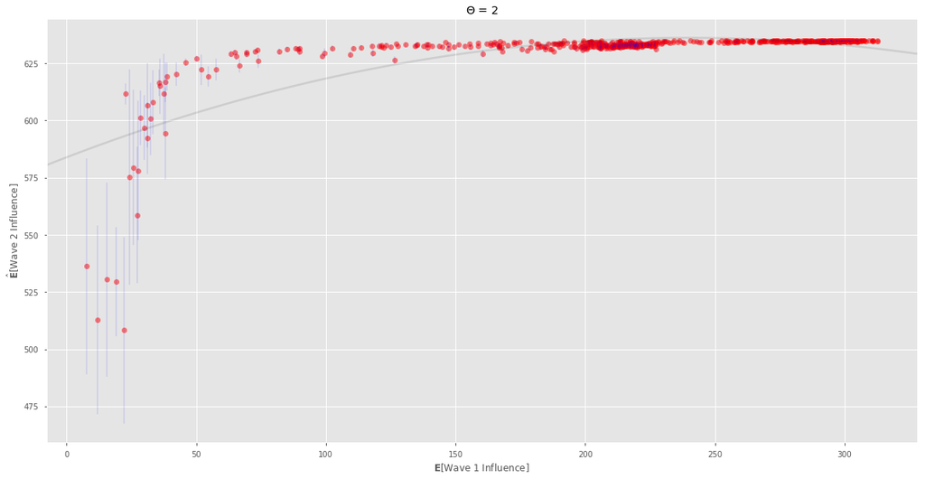

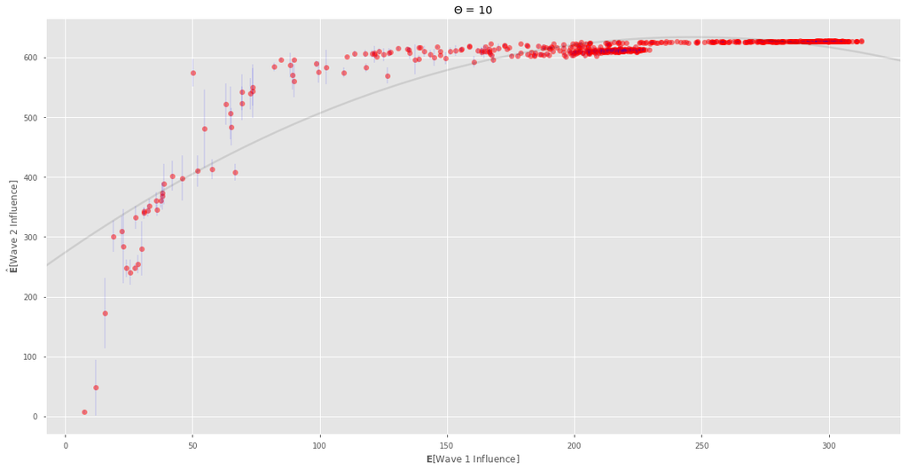

```python
[plot_reg_waves(i) for i in [2, 10]];
```

As expected, for small (and unrealistic) $\Theta$s, most MPs have close to 100% influence over their peers after 2 waves of propagation. Nothing very interesting can be said about it...

Let us note that MPs with a very small wave_1 influence also have a smaller wave_2 influence with generally high variability which is unsurprising.

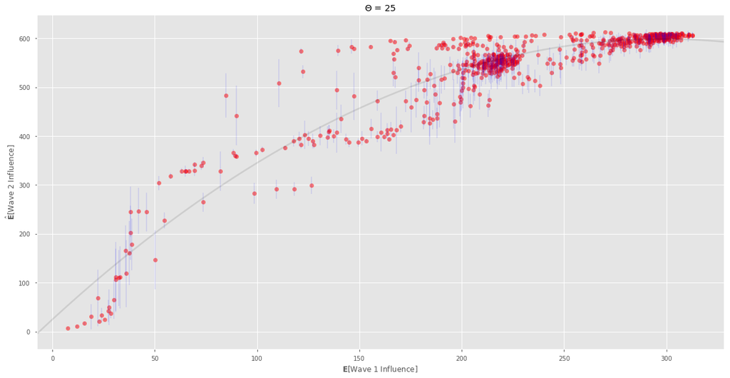

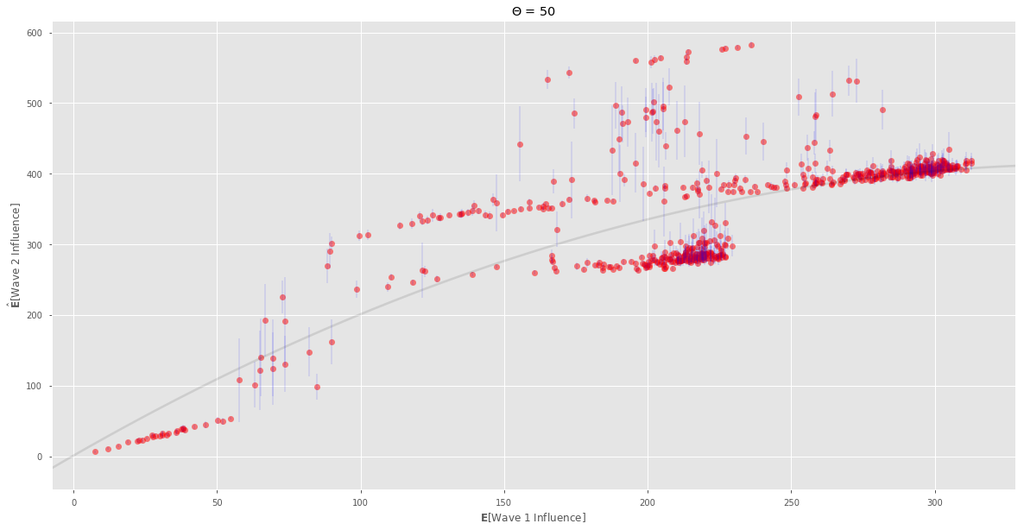

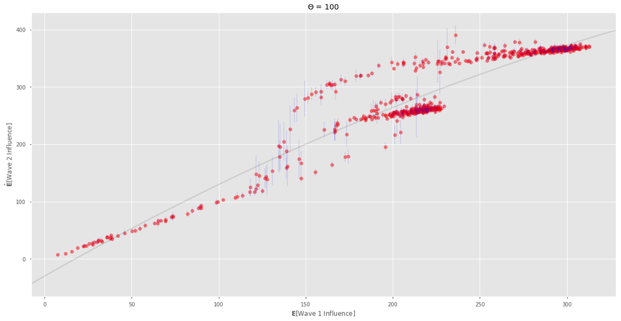

```python
[plot_reg_waves(i) for i in [25, 50, 100]];
```

Using higher $\Theta$, our results are more interesting.

Generally speaking, more influence over your direct neighbors is associated with more influence after 2 waves (see degree 2 polynomial OLS fits in light grey). However, we see that the nodes with the highest wave_2 influence are not necessarily those with the strongest direct influence. This is especially salient using $\Theta = 50$.

Intuitively, observations lying above the line of best-fit are those with *relatively* "few" direct influence on other nodes, but whose connected nodes are themselves endowed with a lot of influence over the network. Conversely, nodes lying below the line are relatively very well connected but their connections themselves have less impact on their peers.

At $\Theta = \{50, 100\}$, we observe that, as predicted, MPs with too low wave_1 influence lie on the 45° line (i.e. their wave_2 influence equals their wave_1 influence, see above).

We can clearly identify two main clusters as $\Theta$ increases, which I suspect correspond to the two main political parties.

#### Let's plot a couple of MP names on the $\Theta = 50$ in order to check whether those two clusters indeed corresponds to political parties.

```python
# Select interesting points for annotating

mean_wave_1 = np.mean(ranking["Expected_Direct_Influence"])
mean_wave_2 = np.mean(ranking["Estimated_2_Waves_Influence_50"])

very_high = ranking.loc[(ranking["Estimated_2_Waves_Influence_50"] > 520), :]
below_below = ranking.loc[((ranking["Expected_Direct_Influence"] < mean_wave_1) & (ranking["Estimated_2_Waves_Influence_50"] < mean_wave_2)), :]
above_below = ranking.loc[((ranking["Expected_Direct_Influence"] > mean_wave_1) & (ranking["Estimated_2_Waves_Influence_50"] < mean_wave_2)), :]
below_above = ranking.loc[((ranking["Expected_Direct_Influence"] < mean_wave_1) & (ranking["Estimated_2_Waves_Influence_50"] > mean_wave_2)), :]
above_above = ranking.loc[((ranking["Expected_Direct_Influence"] > mean_wave_1) & (ranking["Estimated_2_Waves_Influence_50"] > mean_wave_2)), :]
```

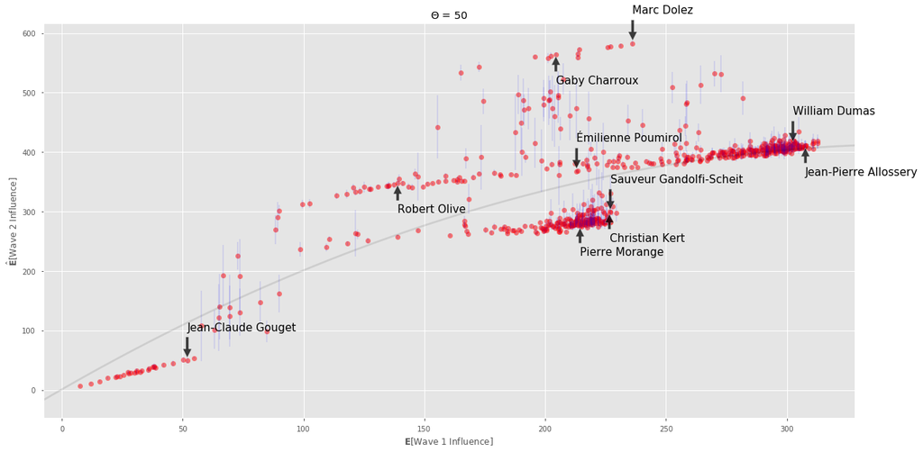

```python
# Get Confidence Interval for our estimated 2nd wave effects

plot_reg_waves(50)

np.random.seed(5)
to_plot = np.array([below_below["MP"].sample(2), # Plot the names of 8 MPs selected at random.
              above_above["MP"].sample(2),
              above_below["MP"].sample(2),
              below_above["MP"].sample(2),
              very_high["MP"].sample(2)]).flatten()

k = 50
for i in to_plot:
    plt.annotate(s = i,
                 xy = (ranking.loc[ranking["MP"] == i, "Expected_Direct_Influence"],
                      ranking.loc[ranking["MP"] == i, "Estimated_2_Waves_Influence_50"]),


                 size = 15,


                 xytext=(ranking.loc[ranking["MP"] == i, "Expected_Direct_Influence"],
                      ranking.loc[ranking["MP"] == i, "Estimated_2_Waves_Influence_50"] + k),


                 arrowprops=dict(facecolor='black', shrink=.1, alpha = .75))

    k = k * -1
```

We indeed have:

- **Pierre Morage**, **Christian Kert**, **Sauveur Gandolfi-Scheit** are from the center-right, main opposition party.
- **William Dumas**, **Jean-Pierre Allossery** are from the majority center-left party. **Emilienne Poumirol** and **Robert Olive** too, but they have only been MPs for 2 years! It therefore makes sense that they have relatively less direct impact than their peers but roughly the same wave_2 influence (their are connected to the majority party). **Jean-Claude Gouget** became a minister after 1 year as a MP.
- **Marc Dolez** and **Gaby Charroux** are communists, as mentionned before.

### $\Longrightarrow$ As a conclusion, we can see that projecting MPs into their wave_1 / wave_2 influence produces a very good clustering of MPs according to their political parties! The Lobbyist model is therefore quite useful in that regard.

Again, being able to color MPs according to their political parties would really be a great next step...

*Clusters can be seen very well using hexbin plots from the seaborn library:*

```
Clusters of MPs can be seen very well using hexbin plots from the seaborn library:
```

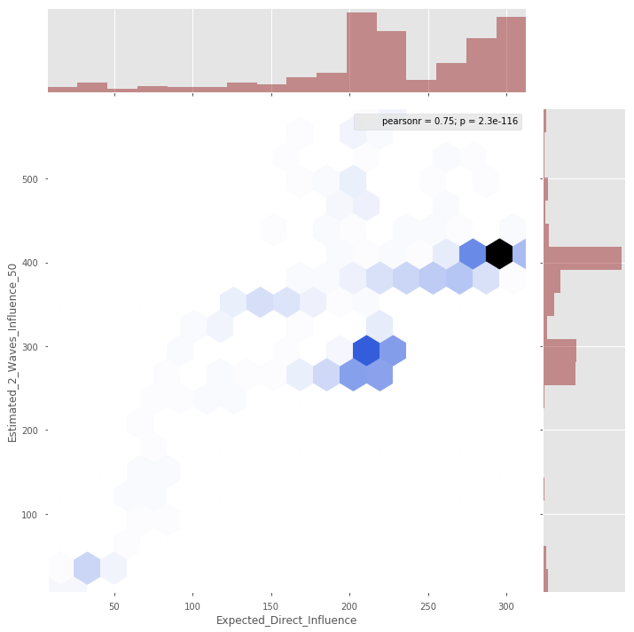

```python
# Plot & Fit
print('Clusters of MPs can be seen very well using hexbin plots from the seaborn library:');
sns.jointplot(ranking["Expected_Direct_Influence"], ranking["Estimated_2_Waves_Influence_50"], kind = 'hex',
              size = 10, color = 'royalblue', marginal_kws={"color":"darkred"});
```

Finally, here are results for the OLS fit of estimated wave_2 influence into a constant, and Expected_Direct_Influence:

**A 1 MP increase in the direct influence circle of an MP is associated with an average 1.09 MP increase in her indirect (2 waves) influence.**

```python
import statsmodels.api as sm
ols3 = sm.formula.ols("Estimated_2_Waves_Influence_50 ~ Expected_Direct_Influence", ranking)
ols3 = ols3.fit(cov_type = "HC2", use_t = True)
print(ols3.summary())
```

```
                                  OLS Regression Results
==========================================================================================
Dep. Variable:     Estimated_2_Waves_Influence_50   R-squared:                       0.564
Model:                                        OLS   Adj. R-squared:                  0.564
Method:                             Least Squares   F-statistic:                     643.0
Date:                            Wed, 09 May 2018   Prob (F-statistic):           1.95e-98
Time:                                    11:19:07   Log-Likelihood:                -3557.4
No. Observations:                             635   AIC:                             7119.
Df Residuals:                                 633   BIC:                             7128.
Df Model:                                       1
Covariance Type:                              HC2
=============================================================================================
                                coef    std err          t      P>|t|      [0.025      0.975]
---------------------------------------------------------------------------------------------
Intercept                    97.1514     11.486      8.458      0.000      74.595     119.707
Expected_Direct_Influence     1.0926      0.043     25.358      0.000       1.008       1.177
==============================================================================
Omnibus:                      199.302   Durbin-Watson:                   1.880
Prob(Omnibus):                  0.000   Jarque-Bera (JB):              510.875
Skew:                           1.608   Prob(JB):                    1.16e-111
Kurtosis:                       5.995   Cond. No.                         819.
==============================================================================

Warnings:
[1] Standard Errors are heteroscedasticity robust (HC2)
```

# ANNEX: All Years Together Network EDA

I start by plotting the influence of our choice of threshold on several degree statistics:

```python
average_connect = []
max_connect = []
median_connect = []
min_connect = []
num_isolates = []
for i in np.arange(0, 1, .05):
    ballot = nx.from_numpy_matrix(yearly_sparse_matrix(allballots, i))
    num_isolates.append(len(nx.isolates(ballot)))

    ballot.remove_nodes_from(list(nx.isolates(ballot)))

    average_connect.append(np.mean(list(nx.average_degree_connectivity(ballot).values())))

    max_connect.append(np.max(list(nx.average_degree_connectivity(ballot).values())))

    median_connect.append(np.median(list(nx.average_degree_connectivity(ballot).values())))

    min_connect.append(np.min(list(nx.average_degree_connectivity(ballot).values())))



results = pd.DataFrame(np.transpose([np.arange(0, 1, .05), average_connect,
                                     max_connect, median_connect,
                                     min_connect, num_isolates]),
                       columns = ["threshold", "average_connect", "max_connect", "median_connect", "min_connect", "num_isolates"])
```

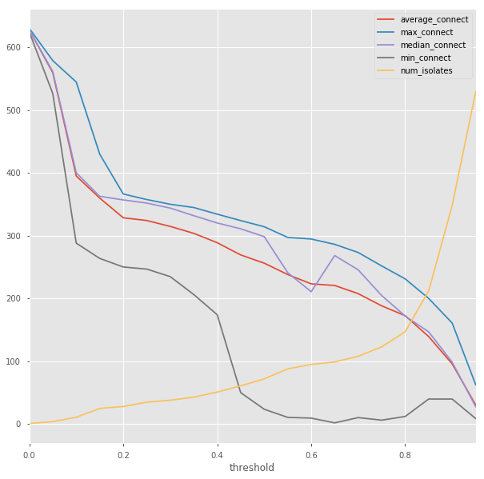

```python
results.plot(x="threshold", figsize = (10, 10));
```

Again, I settle for a threshold of .5.

```python
ballot = nx.from_numpy_matrix(yearly_sparse_matrix(allballots, 0.5))
mapping = dict(zip(ballot.nodes(), allballots[0].index)) # create mapping node/MP
ballot = nx.relabel_nodes(ballot, mapping, copy = False)
```

This creates a high number of isolates (which is normal because many MPs are not even present for more than 50% of the ballots across 5 years):

```python
len(nx.isolates(ballot))
```

```
72
```

```python
ballot.remove_nodes_from(nx.isolates(ballot))
```

We can now plot the network as before: interestingy enough, it is fully connected but with a "high" diameter which may have to do with the temporality of the graph (some MPs never were present at the National Assembly together).

```
Density: 0.45351019739742765, Diameter: 6
```

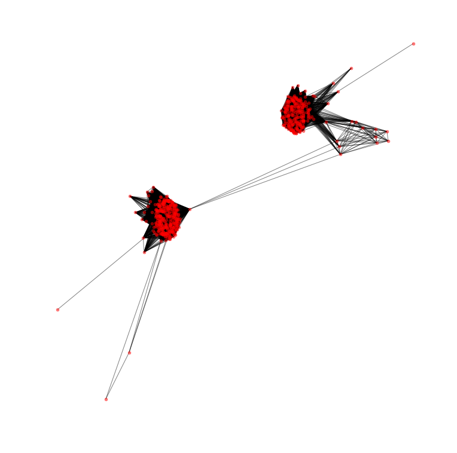

```python
plt.figure(figsize=(10, 10))
nx.draw_spring(ballot, node_size=100, node_shape = '.', linewidths=None,
                 alpha = 0.5, with_labels = False)
print('Density: {}, Diameter: {}'.format(nx.density(ballot), nx.diameter(ballot)))
```

### Vincent Viers — ECON 142: Applied Econometrics and Public Policy